# Math 421 - Midterm

Plot 10

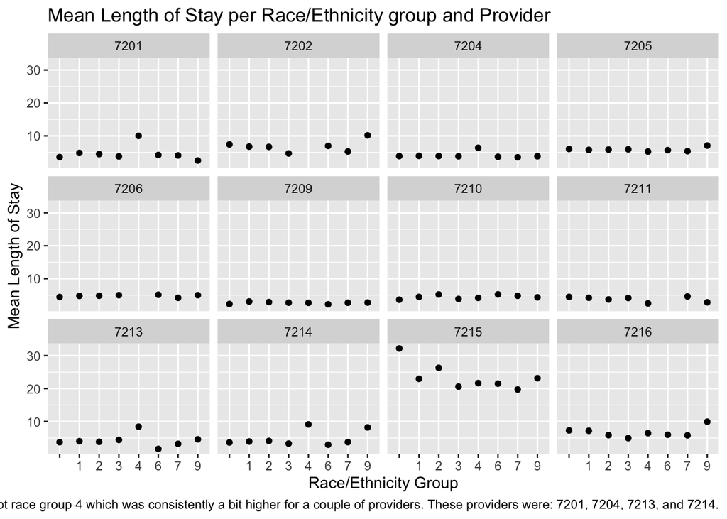

```r
df %>% group_by(provider, raceethn) %>% summarise(mean_los = mean(los)) %>% ggplot()+
  geom_point(mapping=aes(x=raceethn, y=mean_los))+facet_wrap(~provider) + labs(x='Race/Ethnicity Group',
       y = 'Mean Length of Stay',
       title = 'Mean Length of Stay per Race/Ethnicity group and Provider',
       caption = 'Lastly, I wanted to see what the average length of stays were for each race/ethnicity group with respect to each provider, in order to analyze if providers also had any biases towards specific race/ethnicity groups. It turned out that most lengths of stays were practically on par with each other, except race group 4 which was consistently a bit higher for a couple of providers. These providers were: 7201, 7204, 7213, and 7214.')
```

Observation: Lastly, I wanted to see what the average length of stays were for each race/ethnicity group with respect to each provider, in order to analyze if providers also had any biases towards specific race/ethnicity groups. It turned out that most lengths of stays were practically on par with each other, except race group 4 which was consistently a bit higher for a couple of providers. These providers were: ‘7201’, ‘7204’, ‘7213’, and ‘7214’.

2. Make an animation plot.

[figure not shown]

```r
g <- ggplot(df,
       aes(x = provider,
           y = tot,
           fill = provider))+
  geom_col() +
  transition_states(moa) + labs(title='Month: {moa}')
animate(g)
```

3. Write a paragraph to summarize the section and give your comments on the results.

While creating all of these plots, it was interesting to analyze all the data I was able to visualize. First of all, it was nice to be able to explore the data with graphs and get to know the data set and how many men or women there were. It was also cool to see how men had a higher average total charge, but due to exploring the data set better, instead of making quick conclusions, I tied it to something important I found, and that was that males had a higher average ge than females. Since covid hit older patients harder, this may have been the main contributor that led to males having higher average charges. Adding on, seeing how patients’ average length of stays changed drastically depending on which provider they had and what age they were, was a very interesting find. Lastly, spotting the differences in charges and average lengths of stay between race and ethnicity groups was pretty surprising, I did not feel like this would be something that caused differences, but it ended up playing a big role in the data set.

## III. Predictive Models

Continue with the data from part I. Make sure you do not have any missing values in the data. Use the follows as the target and input variables:

```r
df <- read_csv('midterm.csv')
```

*Target Variable*: Create the target variable taking value of

- `low` if the total charge of a patient (`tot`) is smaller than the median of the total charge, and

```r
df$target <- case_when(df$tot<=21854 ~ 'low', df$tot>=21854 ~ 'high')
```

- `high` otherwise.

*Input Variables*:

- “age”,“sex”,“raceethn”,“provider”,“moa”,“mod”,“admtype”,“campus”, ‘los’

```r
df <- df %>% select("age","sex","raceethn","provider","moa","mod","admtype","campus", 'los','target')
df <- drop_na(df)
```

1. Use `filter` function to filter out rows where `raceethn==''` or `admtype==''`. Make sure all the categorical variables are factor, numeric variables are numeric. Set Training : Testing Split = 10 : 90

```r
df <- df %>% filter((!raceethn=='') & (!admtype=='')) %>% mutate(sex = as.factor(sex),
         raceethn = as.factor(raceethn), provider = as.factor(provider), moa = as.factor(moa), mod = as.factor(mod), admtype = as.factor(admtype), campus = as.factor(campus), los = as.factor(los))
```

```r
library(caret)
splitIndex <- createDataPartition(df$target, p = .01,
                                  list = FALSE)
df_train <- df[ splitIndex,]
df_test <- df[-splitIndex,]
```

2. Train a decision tree using `rpart`. Plot the decision tree. Plot the variable importance ranked by the tree.

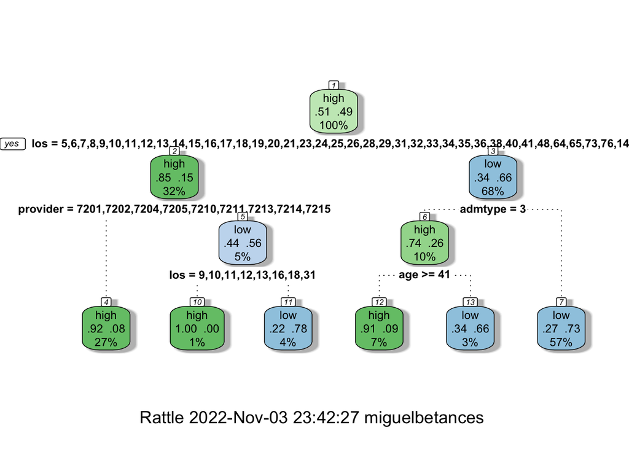

```r
library(rpart)
tree_model <- rpart(target ~ ., data = df_train,
                 control = rpart.control(maxdepth = 3))
library(rattle)
fancyRpartPlot(tree_model)
```

```r
tree_model$variable.importance
```

```
##        los    admtype   provider        age   raceethn     campus        mod
## 157.599232  49.610300  41.356996  18.531227   3.615849   3.305611   2.212851
##        moa
##   1.332416
```

3. Using caret for this question. Set `Training Control` to be: Use Cross-Validation of 5 folds across all models. Train & tune at least 2 different models (i.e. two different values for `method=` in the train function of caret). Plot the hyper-parameter tuning plots for each model.

Plot 1

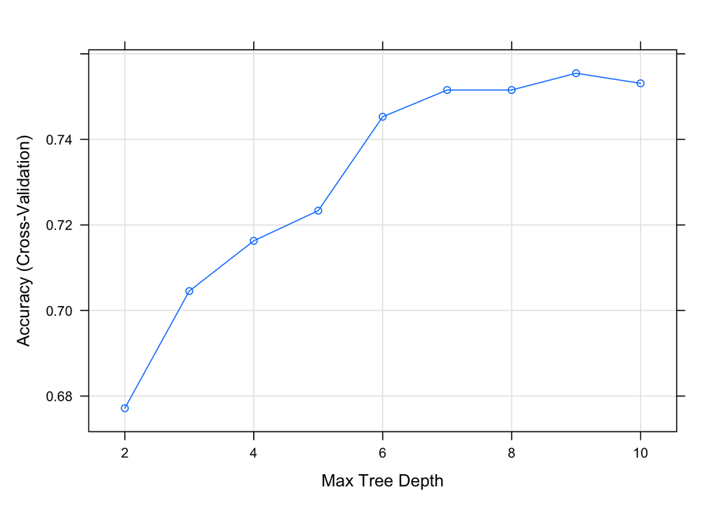

```r
tuneGrid = expand.grid(maxdepth = 2:10)
trControl = trainControl(method = "cv",
                         number = 5)
tree_approach_2 <- train(target~., data=df_train,
                                method = "rpart2",
                                trControl = trControl,
                                tuneGrid = tuneGrid)
plot(tree_approach_2)
```

Plot 2

```r
trControl = trainControl(method = "cv",
                         number = 5)
tuneGrid = expand.grid(mtry = 2:4,
                       splitrule = c('gini', 'extratrees'),
                       min.node.size = c(1:10))
forest_ranger <- train(target~., data=df_train,
                    method = "ranger",
                    trControl = trControl,
                    tuneGrid = tuneGrid)
```

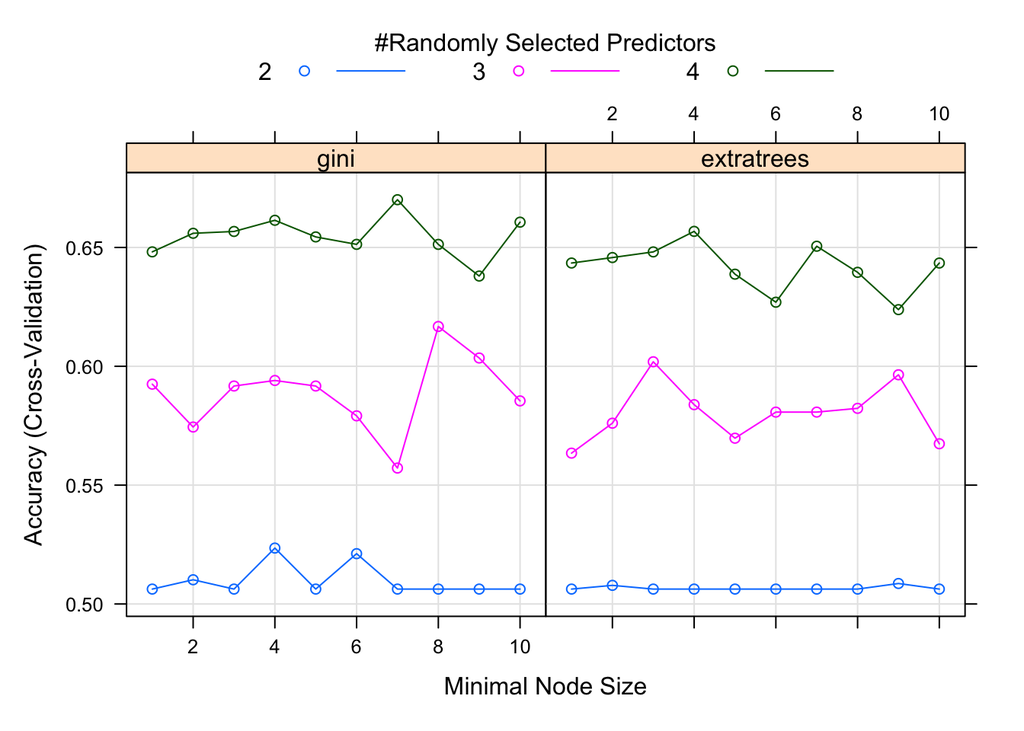

```r
plot(forest_ranger)
```

4. Plot the comparison of the models in 3.

Plot 1

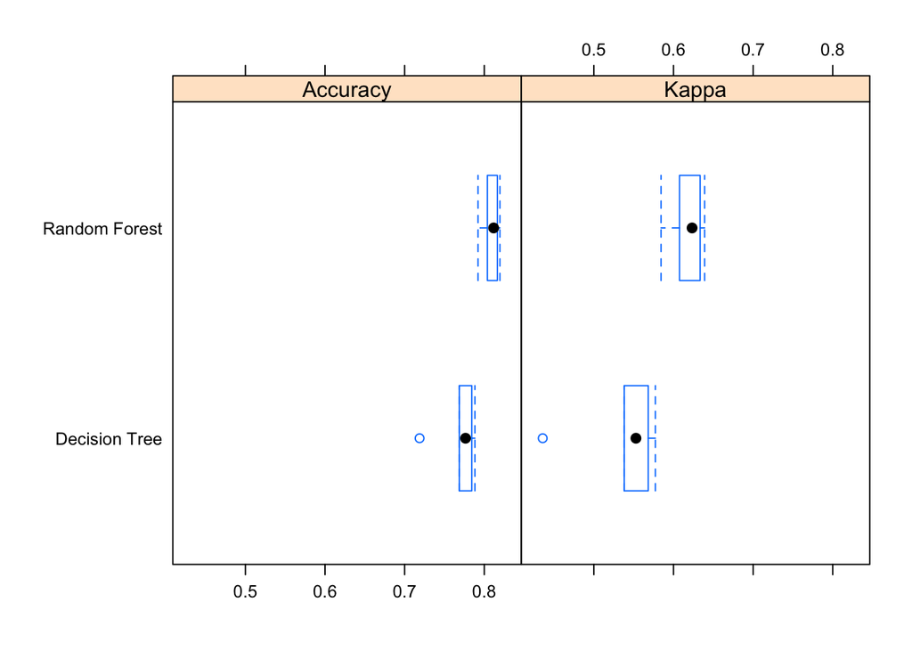

```r
trControl = trainControl(method = "cv",
                         number = 5)
tree_approach_2 <- train(target~., data=df_train,
                                method = "rpart2",
                                trControl = trControl)
forest_ranger <- train(target~., data=df_train,
                    method = "ranger",
                                trControl = trControl)


results <- resamples(list('Decision Tree' = tree_approach_2,
                          'Random Forest' = forest_ranger))
bwplot(results)
```

5. What is your final selection for the model? Test the accuracy of your final model on the test data.

The decision is to use the random forest instead of the decision tree. The random forest has both a higher Accuracy, and a higher Kappa statistic

```r
pred <- predict(forest_ranger, df_test)
cm <- confusionMatrix(data = pred, reference = as.factor(df_test$target))
cm$overall[1]
```

```
## Accuracy
## 0.792271
```

6. Create another `target` variable (binary), decide the input variables and redo 1 to 5.

```r
df$los = as.numeric(df$los)
df$target_los <- case_when(df$los<mean(df$los) ~ 'low', df$los>mean(df$los) ~ 'high')
```

```r
df <- df %>% filter((!raceethn=='') & (!admtype=='')) %>% mutate(sex = as.factor(sex),
         raceethn = as.factor(raceethn), provider = as.factor(provider), moa = as.factor(moa), mod = as.factor(mod), admtype = as.factor(admtype), campus = as.factor(campus), los = as.factor(los))
```

```r
library(caret)
splitIndex <- createDataPartition(df$target_los, p = .01,
                                  list = FALSE)
df_train <- df[ splitIndex,]
df_test <- df[-splitIndex,]
```

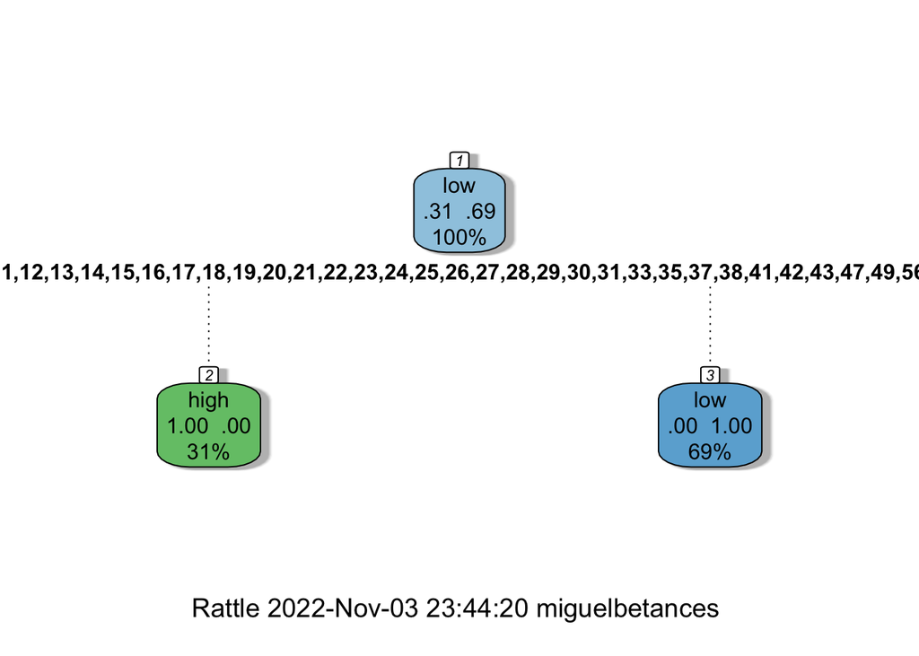

```r
library(rpart)
tree_model_los <- rpart(target_los ~ ., data = df_train,
                 control = rpart.control(maxdepth = 3))
library(rattle)
fancyRpartPlot(tree_model_los)
```

```r
tree_model_los$variable.importance
```

```
##        los     target   provider    admtype
## 549.216301  67.278997  15.103448   4.119122
```

```r
tree_model_los$variable.importance
```

```
##        los     target   provider    admtype
## 549.216301  67.278997  15.103448   4.119122
```

Plot 1

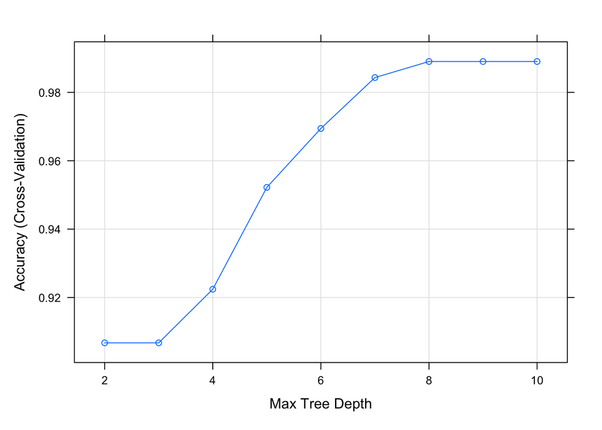

```r
tuneGrid = expand.grid(maxdepth = 2:10)
trControl = trainControl(method = "cv",
                         number = 5)
tree_approach_2_los <- train(target_los~., data=df_train,
                                method = "rpart2",
                                trControl = trControl,
                                tuneGrid = tuneGrid)
plot(tree_approach_2_los)
```

Plot 2

```r
trControl = trainControl(method = "cv",
                         number = 5)
tuneGrid = expand.grid(mtry = 2:4,
                       splitrule = c('gini', 'extratrees'),
                       min.node.size = c(1:10))
forest_ranger_los <- train(target_los~., data=df_train,
                    method = "ranger",
                    trControl = trControl,
                    tuneGrid = tuneGrid)
```

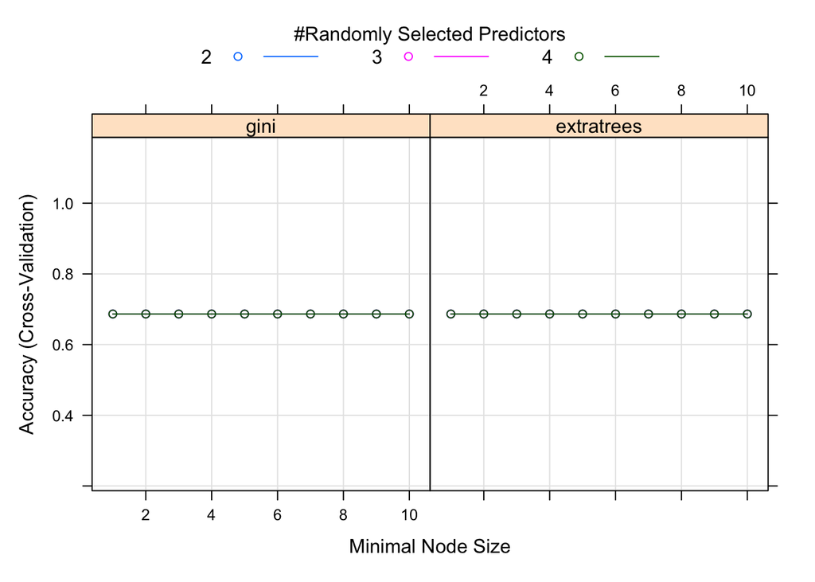

```r
plot(forest_ranger_los)
```

Plot 1

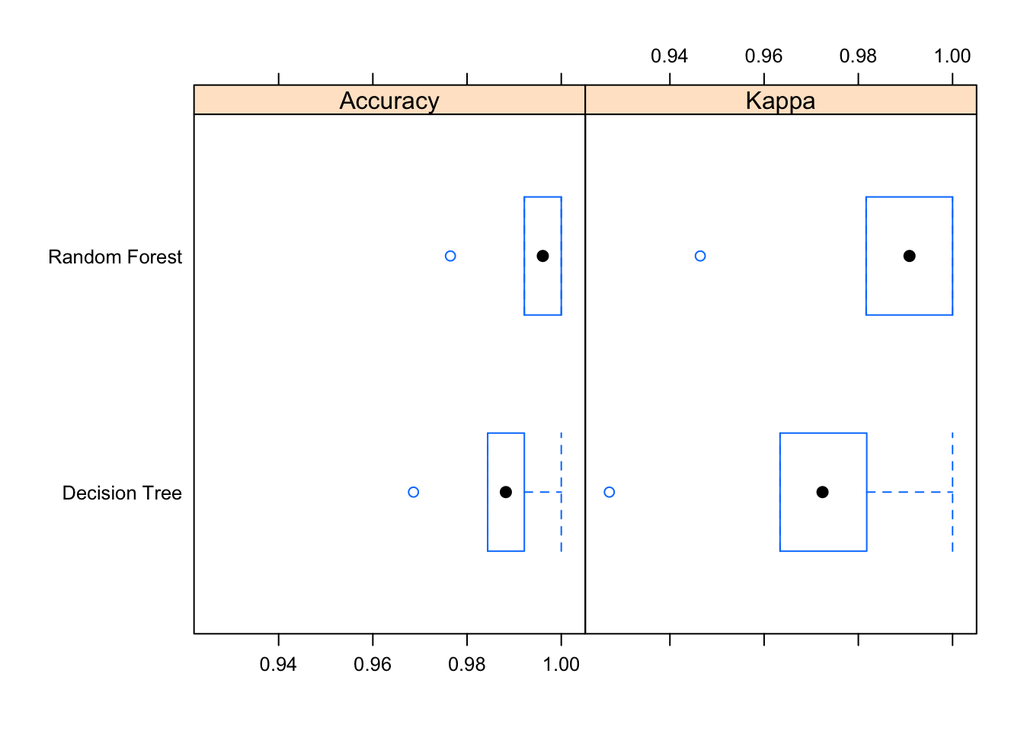

```r
trControl = trainControl(method = "cv",
                         number = 5)
tree_approach_2_los <- train(target_los~., data=df_train,
                                method = "rpart2",
                                trControl = trControl)
forest_ranger_los <- train(target_los~., data=df_train,
                    method = "ranger",
                                trControl = trControl)


results_los <- resamples(list('Decision Tree' = tree_approach_2_los,
                          'Random Forest' = forest_ranger_los))
bwplot(results_los)
```

The decision is to use the random forest instead of the decision tree. The random forest has both a higher Accuracy, and a higher Kappa statistic.

```r
pred <- predict(forest_ranger_los, df_test)
cm <- confusionMatrix(data = pred, reference = as.factor(df_test$target_los))
cm$overall[1]
```

```
##  Accuracy
## 0.9964357
```